# San_Francisco_Crime_Statistics_Without_Code

This notebook looks at the resolution rate of crimes with respect to:

- Time of day
- District
- Type of crime

Resolved crimes are defined as those whose value for the 'Resolution' field is not 'NONE'. Resolution rate is defined as the ratio of resolved crimes to the total number of crimes.

First we find the time of day with the lowest resolution rate. We do this by plotting an hourly time series of resolution rates.

We now plot resolution rate over time. We also plot incidence number as this will put resolution rate in context. For example, we will be able to see whether a particular hour has a high resolution rate simply because it has a low number of crimes.

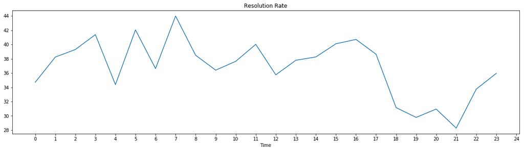

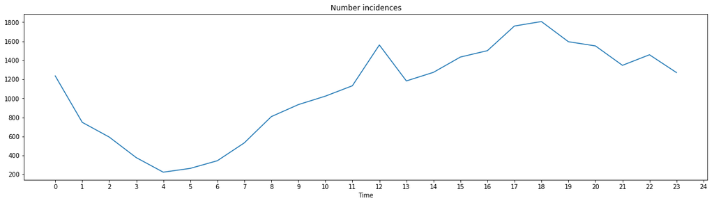

We can see that period with the lowest resolution rate is 6-9pm. This appears to be in part related to the fact that there is a very high number of incidences in this time period. However, note that the number of incidences decreases from 6pm to 9pm but the resolution rate also decreases. So, even though the number of incidences is decreasing, the resolution rate is getting worse.

We now plot the resolution rate and number of incidences by district. We manipulate the frame in a similar way to how we did for time, except we group by district and we use a bar plot instead of a line.

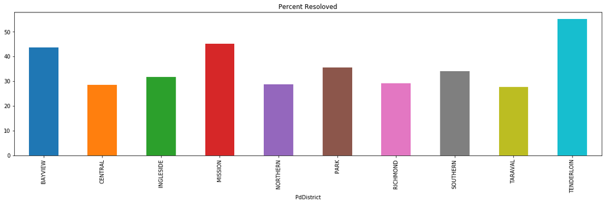

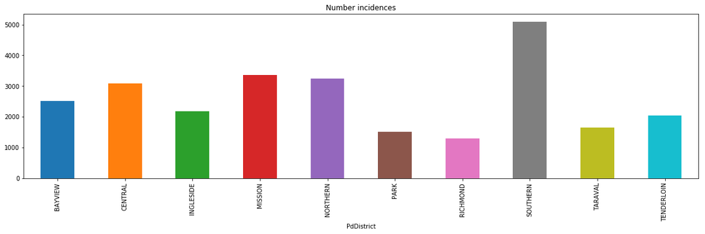

We can see that the districts with the lowest resolution rates are: Central, Ingleside, Northern, Richmond and Taraval. This does not appear to be because of high incidence rates as these districts do not generally have higher incidence rates than the other districts.

We now create a similar graph for resolution rate by crime type.

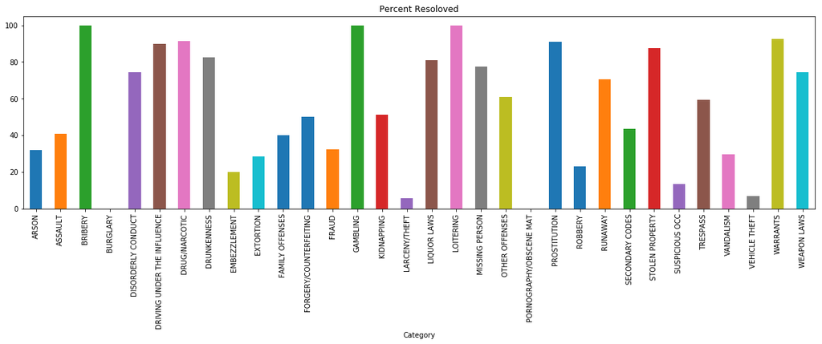

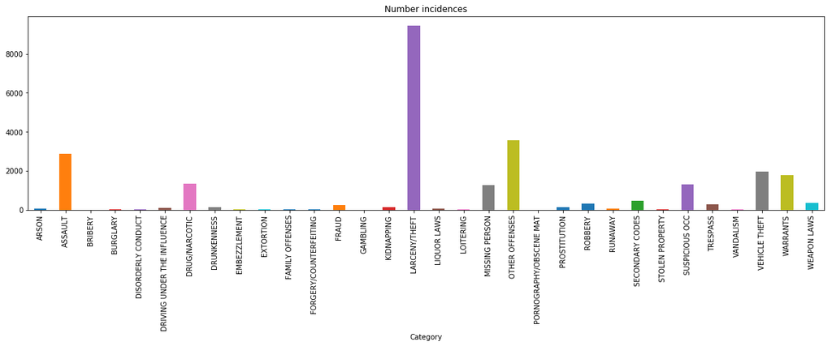

Burglary, Larceny/Theft, Pornography/obscene material and vehicle theft have the lowest resolution rates. In the case of Larceny/Theft and vehicle theft, the low resolution rates appear to be partly due to extremely high incidence rates.

To conclude:

- The time period with the lowest resolution rate is 6pm to 9pm, appearing to be due in part to the high number of incidences in this period.
- The districts with the lowest resolution rates are Central, Ingleside, Northern, Richmond and Taraval.
- The crimes with the lowest resolution rates are Burglary, Larceny/Theft, Pornography/obscene material and vehicle theft. In the case of larceny/theft and vehicle theft, this appears to be partly due to very high incidence rates.